# 자연언어처리 8주차_텍스트 마이닝을 사용한 자연언어처리 #3: 토픽 모델링 및 TF-IDF

## (3) 실습

- 소규모 데이터셋
  - **tidytext** 패키지의 `bind_tf_idf()` 함수를 사용하여 TF-IDF 값 구하기.
  - 문서의 수가 많지 않다면 주제가 아닌, 문서별 TF-IDF도 산출 가능.

```r
library(tidytext)

# 문서별 TF-IDF 값 구한 뒤 상위 10개 단어 추출하기.
set.seed(123) # 난수 고정하기.
document_tf_idf <- article_filtered %>%
  unnest_tokens(word, text, token = "words") %>% # 띄어쓰기 단위로 text 칼럼 토큰화하기.
  count(doc_id, word, sort=TRUE) %>% # 문서+단어 조합의 빈도 계산하기.
  bind_tf_idf(word, doc_id, n) %>% # 문서별 TF-IDF 값 계산하기.
  arrange(-tf_idf) %>% # TF-IDF 값을 기준으로 내림차순 배열하기.
  group_by(doc_id) %>% # 문서를 기준으로 그룹화하기.
  slice_max(tf_idf, n = 10) %>% # 문서별 상위 TF-IDF 10개 단어 추출하기.
  ungroup() # 그룹화 해제하기.

# 결과 확인하기.
document_tf_idf %>%
  arrange(doc_id, desc(tf_idf)) %>% # 문서별로 TF-IDF 값을 내림차순으로 나열하기.
  select(doc_id, word, tf_idf) # 문서, 중요 단어, TF-IDF 값 칼럼만 남기기.
```

```
## # A tibble: 12,425 × 3
##    doc_id        word         tf_idf
##    <chr>         <chr>         <dbl>
##  1 A201008176770 아시아       0.230
##  2 A201008176770 서편제       0.205
##  3 A201008176770 욕망         0.196
##  4 A201008176770 임권택       0.146
##  5 A201008176770 층위         0.145
##  6 A201008176770 서구         0.126
##  7 A201008176770 판소리       0.123
##  8 A201008176770 진입         0.103
##  9 A201008176770 오리엔탈리즘 0.0971
## 10 A201008176770 영화         0.0875
## # ℹ 12,415 more rows
```

```r
# 학문분야별 TF-IDF 값 구한 뒤 상위 10개 단어 추출하기.
article_tf_idf <- article_filtered %>%
  unnest_tokens(word, text, token = "words") %>% # 띄어쓰기 단위로 text 칼럼 토큰화하기.
  count(actual_label, word, sort= TRUE) %>% # 학문분야+단어 조합의 빈도 계산하기.
  bind_tf_idf(word, actual_label, n) %>% # 학문분야별 TF-IDF 값 계산하기.
  arrange(-tf_idf) %>% # TF-IDF 값을 기준으로 내림차순 배열하기.
  group_by(actual_label) %>% # 학문분야를 기준으로 그룹화하기.
  slice_max(tf_idf, n = 10) %>% # 학문분야별 상위 TF-IDF 10개 단어 추출하기.
  ungroup() # 그룹화 해제하기.

# 결과 확인하기.
article_tf_idf %>%
  arrange(actual_label, desc(tf_idf)) %>% # 학문분야별로 TF-IDF 값을 내림차순으로 나열하기.
  select(actual_label, word, tf_idf) # 학문분야, 중요 단어, TF-IDF 값 칼럼만 남기기.
```

```
## # A tibble: 30 × 3
##    actual_label word       tf_idf
##    <chr>        <chr>       <dbl>
##  1 공학         콘크리트 0.00220
##  2 공학         차량     0.00159
##  3 공학         사용자   0.00119
##  4 공학         보안     0.00100
##  5 공학         취약점   0.000780
##  6 공학         균열     0.000751
##  7 공학         교량     0.000693
##  8 공학         시공     0.000693
##  9 공학         포렌식   0.000693
## 10 공학         패킷     0.000664
## # ℹ 20 more rows
```

- **ggplot2**를 사용하여 TF-IDF 분석 결과 시각화하기

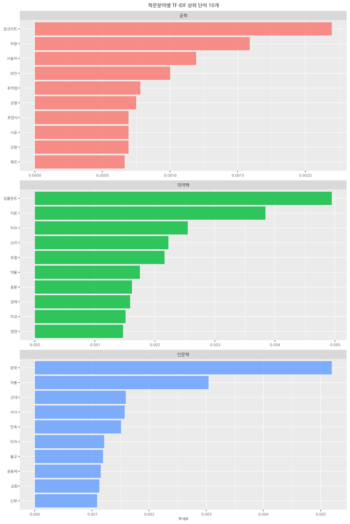

```r
article_tf_idf %>%
    ggplot(aes(x = reorder_within(word, tf_idf, actual_label), y = tf_idf, fill = actual_label)) + # x축은 word, y축은 tf-idf, 색상은 actual_label. x축은 actual_label별로 단어들이 TF-IDF 내림차순으로 배열되도록 하기.
    geom_col(alpha = 0.8, show.legend = FALSE) + # 바의 색상 조정. 범례는 제거.
    facet_wrap(~ actual_label, scales = "free", ncol=1) + # 학문분야 기준으로 다면출력. 일렬로 제시.
    scale_x_reordered() + # x축은 reorder된 상태 유지.
    coord_flip() + # x축과 y축 위치 서로 바꾸기.
    theme(strip.text=element_text(size=14)) + # 다면출력 표제 텍스트 크기 지정하기.
    labs(x = NULL, y = "TF-IDF", # x축 제목은 적지 않고, y축 제목은 "TF-IDF"라고 적음.
         title = "학문분야별 TF-IDF 상위 단어 10개") + # 표 제목 적기.
  theme(text= element_text(family = "NanumGothic"), # 텍스트 폰트 지정하기.
        axis.text.x = element_text(size = 12),  # x축 텍스트 크기.
        axis.text.y = element_text(size = 12),  # y축 텍스트 크기.
        axis.title.y = element_text(size = 16),  # y축 제목 크기.
        plot.title = element_text(size = 16, face = "bold", hjust = 0.5)) # 그래프 제목 크기 설정하기, 굵게 하기, 가운데 정렬하기.
```

- 대규모 데이터셋: **quanteda** 패키지의 `dfm_tfidf()` 함수 사용하여 TF-IDF 값 구하기

```r
library(quanteda)

# 1. corpus 객체 생성하기.
corp <- corpus(article_filtered, text_field = "text", docid_field = "doc_id")

# 2. 토큰화 및 DFM(Document-Feature Matrix) 생성하기.
dfm_mat <- corp %>%
  tokens(remove_punct = TRUE, remove_numbers = TRUE) %>% # 구두점과 숫자 없애기.
  dfm(tolower = TRUE) # 소문자 변환 포함.

# 3. 학문분야별로 그룹화하여 TF-IDF 계산하기.
dfm_grouped <- dfm_mat %>%
  dfm_group(groups = article_filtered$actual_label) %>% # 논문초록 데이터셋의 학문분야 칼럼(actual_label)을 기준으로 그룹화하기.
  dfm_tfidf() # TF-IDF 계산하기.

# 4. tidy 형태로 변환하기.
dfm_tidy <- tidy(dfm_grouped) # 결과: document, term, count(여기서 count는 TF-IDF).

# 5. 학문분야별로 상위 20개 단어 추출하기.
top_terms_by_field <- dfm_tidy %>%
  rename(field = document, tfidf = count) %>%
  group_by(field) %>%
  slice_max(order_by = tfidf, n = 20, with_ties = FALSE) %>%
  ungroup()
top_terms_by_field
```

```
## # A tibble: 60 × 3
##    field term     tfidf
##    <chr> <chr>    <dbl>
##  1 공학  콘크리트  36.3
##  2 공학  차량      26.2
##  3 공학  사용자    19.7
##  4 공학  보안      16.6
##  5 공학  취약점    12.9
##  6 공학  균열      12.4
##  7 공학  교량      11.5
##  8 공학  시공      11.5
##  9 공학  포렌식    11.5
## 10 공학  패킷      11.0
## # ℹ 50 more rows
```

# 7. TF-IDF vs. LDA 비교

## (1) 개별 문서의 중요 단어 추출하기

```r
# 1. 예시문서 선택하기.
doc_example <- "A201008199791"

# 2. 모든 문서의 TF-IDF 값 계산 후 예시문서만 필터링하여 TF-IDF 상위 10개 단어 추출하기.
set.seed(123) # 난수 고정하기.
document_tf_idf_1 <- article_filtered %>%
  unnest_tokens(word, text, token = "words") %>% # 띄어쓰기 단위로 text 칼럼 토큰화하기.
  count(doc_id, word, sort=TRUE) %>% # 모든 문서별 단어 빈도 계산하기.
  bind_tf_idf(word, doc_id, n) %>% # 모든 문서의 TF-IDF 값 계산하기.
  filter(doc_id == doc_example) %>% # 해당 문서만 필터링하기.
  slice_max(tf_idf, n = 10) # 해당 문서의 TF-IDF 상위 10개 단어 추출하기.
```

## (2) 개별 문서의 주제와 해당 주제의 대표 단어 추출하기

```r
# 1. 예시문서 선택하기.
doc_example <- "A201008199791"

# 2. 문서별 주제 분포 행렬 추출하기.
gamma_matrix <- posterior(article_lda)$topics # 행 = 문서, 열 = 주제.

# 3. tidy 형태로 변환하기.
topic_distribution <- gamma_matrix %>%
  as_tibble() %>% # 행렬을 티블로 바꾸기.
  mutate(doc_id = article_filtered$doc_id) %>% # 원래 말뭉치의 문서 식별자 직접 삽입하기.
  pivot_longer(cols = -doc_id,             # doc_id 칼럼을 제외한 모든 칼럼의 제목에 대해서..
               names_to = "topic",         # topic 칼럼 밑에 행으로 넣어라!
               values_to = "gamma") %>%    # doc_id 칼럼을 제외한 모든 칼럼(`1`, `2`, `3`로 되어 있던 칼럼) 밑에 있던 값들은 gamma라는 새로운 칼럼을 만들어 그리로 넣어라!
  mutate(topic = parse_number(topic))      # topic 칼럼의 행을 숫자로 만들어라!
topic_distribution
```

```
## # A tibble: 3,600 × 3
##    doc_id        topic gamma
##    <chr>         <dbl> <dbl>
##  1 A201008192866     1 0.245
##  2 A201008192866     2 0.541
##  3 A201008192866     3 0.213
##  4 A201008192914     1 0.144
##  5 A201008192914     2 0.698
##  6 A201008192914     3 0.158
##  7 A201008192630     1 0.304
##  8 A201008192630     2 0.223
##  9 A201008192630     3 0.473
## 10 A201008183004     1 0.162
## # ℹ 3,590 more rows
```

```r
# 4. 해당 문서의 대표 주제 추출하기.
gamma_doc <- topic_distribution %>%
  filter(doc_id == doc_example) %>%  # 해당 문서의 주제분포 추출하기.
  slice_max(gamma, n = 1) # 가장 확률 높은 주제 선택하기.
gamma_doc
```

```
## # A tibble: 1 × 3
##   doc_id        topic gamma
##   <chr>         <dbl> <dbl>
## 1 A201008199791     2 0.432
```

```r
top_topic <- gamma_doc$topic # 해당 문서의 주요 주제번호 저장하기.

lda_terms <- abs_top_terms %>% # 주제별 최빈 단어 10개 모음.
  filter(topic == top_topic) # 해당 문서가 속한 주제의 대표 단어 추출하기.
lda_terms
```

```
## # A tibble: 10 × 3
##    topic term      beta
##    <int> <chr>    <dbl>
##  1     2 방법   0.0145
##  2     2 이용   0.0115
##  3     2 결과   0.0109
##  4     2 사용   0.0108
##  5     2 적용   0.00946
##  6     2 제안   0.00911
##  7     2 분석   0.00904
##  8     2 기반   0.00802
##  9     2 시스템 0.00791
## 10     2 수행   0.00737
```

# 8. 문서 유사도 기반 추천 시스템

## (1) 원리와 기제

- 정의: 한 문서와 내용적으로 가장 비슷한 다른 문서를 찾아주는 알고리즘. 정보검색, 콘텐츠 추천, 자동분류 등에 널리 활용됨.
- 핵심원리
  - 문서 벡터화
    - 각 문서를 수치화된 벡터로 변환.
    - 대표 방식: TF-IDF, 단어 임베딩(word embedding), Doc2Vec 등.
  - 유사도 계산
    - 벡터 간 유사도를 수치로 계산.
    - 대표 지표: 코사인 유사도, 유클리드 거리, 자카드 유사도 등.
  - 가장 유사한 문서 선택: 기준 문서와 유사도가 높은 문서들을 상위 n개 추천.
- 의의: 단순한 기술이 아니라, 텍스트 간 의미적 유사성을 정량화하는 사고도구임.
- TF-IDF 행렬
  - TF-IDF는 문서 내 단어의 중요도를 수치화한 값.
  - 각 문서를 벡터로 표현하며, 행은 문서, 열은 단어, 셀 값은 해당 단어의 TF-IDF 점수가 됨.

**[표 4] TF-IDF 행렬 예시**

| 문서 | 단어1 | 단어2 | 단어3 |
| --- | --- | --- | --- |
| A | 0.21 | 0.00 | 0.35 |
| B | 0.00 | 0.18 | 0.00 |

- 희소행렬(sparse matrix)
  - 대부분의 값이 0인 행렬.
  - 전체 말뭉치는 단어의 가짓수가 많지만, 한 문서에 등장하는 단어는 그 중 일부에 지나지 않음. 따라서 TF-IDF 행렬은 자연스럽게 희소행렬이 됨.

**[표 5] TF-IDF 행렬과 희소행렬의 유사점**

| 항목 | 설명 |
| --- | --- |
| 구조 | 둘 다 행 = 문서, 열 = 단어 형태의 행렬 |
| 목적 | 문서를 수치화하여 벡터로 표현 |
| 활용 | 문서 유사도 계산, 분류, 클러스터링 등 |

**[표 6] TF-IDF 행렬과 희소행렬의 차이점**

| 항목 | TF_IDF_행렬 | 희소행렬 |
| --- | --- | --- |
| 정의 | 단어 중요도를 반영한 수치 행렬 | 값 대부분이 0인 행렬구조 |
| 의미 | 단어의 빈도와 희귀성을 반영 | 구조적 특성(메모리 효율) 중심 |
| 생성방식 | TF-IDF 알고리즘 기반 | 구조적으로 자동 생성됨 |
| 사용목적 | 정보검색, 추천, 분류 | 계산 최적화, 메모리 절약 |

## (2) 문서 유사도 기반 추천 시스템 생성 실습

### 1) 문서 유사도 기반 추천 시스템 생성하기

```r
library(text2vec) # 텍스트 유사도 계산용 패키지.

# 1. 모든 문서에 대한 TF-IDF 구하기.
all_doc_tf_idf <- article_filtered %>%
  unnest_tokens(word, text, token = "words") %>% # 띄어쓰기 단위로 text 칼럼 토큰화하기.
  count(doc_id, word, sort=TRUE) %>% # 모든 문서별 단어 빈도 계산하기.
  bind_tf_idf(word, doc_id, n)

# 2. TF-IDF 행렬을 희소행렬로 변환하기.
tfidf_matrix <- cast_sparse(all_doc_tf_idf, doc_id, word, tf_idf)

# 3. 문서들 간 코사인 유사도 계산하기.
similarity_matrix <- sim2(tfidf_matrix, method = "cosine", norm = "l2")

# 4. 문서 유사도 기반 추천 시스템 함수 만들기.
recommend_similar_docs <- function(doc_id, top_n = 5) {
  scores <- similarity_matrix[doc_id, ]     # 해당 문서와 다른 문서 간 유사도 추출하기.
  scores[doc_id] <- NA                      # 자기 자신은 제외하기.
  top_docs <- sort(scores, decreasing = TRUE)[1:top_n]  # 유사도 상위 문서 5개 추출하기.
  return(names(top_docs))                   # 추천 문서 식별자 반환하기.
}

# 5. 문서 A201008199791과 유사한 문서 5개 추천하기.
top_5_recommend <- recommend_similar_docs("A201008199791")
top_5_recommend
```

```
## [1] "A201008199975" "A201008193059" "A201008194798" "A201008206947"
## [5] "A201008204665"
```

### 2) 추천결과와 실제 학술분야 비교하기

```r
# A201008199791 문서의 원래 학술분야 확인하기.
article_filtered %>%
  filter(doc_id == "A201008199791" ) # 공학 분야 논문초록.
```

```
## # A tibble: 1 × 3
##   actual_label doc_id
##   <chr>        <chr>
## 1 공학         A201008199791
##   text
##   <chr>
## 1 유비쿼터스 컴퓨팅 시대 등장 인간 정보 기술 활용 욕구 발전 단계 필연 등장 정보 기술 패러다임 지금 국가 정보 과정 정부 사회 개인 정보…
```

```r
# 추천받은 5개 논문초록의 실제 학술분야 확인하기.
article_filtered %>%
  filter(doc_id %in% top_5_recommend) # 공학 분야 4개 + 의약학 분야 1개 추천.
```

```
## # A tibble: 5 × 3
##   actual_label doc_id
##   <chr>        <chr>
## 1 공학         A201008194798
## 2 공학         A201008206947
## 3 공학         A201008193059
## 4 공학         A201008199975
## 5 의약학       A201008204665
##   text
##   <chr>
## 1 우리나라 국무 회의 에너지 기본 계획 심의 확정 고 에너지 기본 계획 주요 내용 요약 정리 계획 에너지 정책 비전 기본 방향 제시 대 중점…
## 2 의료 기관 개인 정보 보호 가이드라인 미국 영국 나라 진행 상태 곳 발표 국내 경우 국내 의료 기관 특화 가이드라인 제시 실정 미래 창조 …
## 3 다수 민간 기업체 공공 기관 영업 홍보 민원 처리 업무 다양 방법 개인 정보 수집 조직 이익 업무 처리 개인 정보 활용 수집 개인 정보 기…
## 4 전화기 프리미엄 경쟁 신청 일 전 국민 절반 이상 휴대폰 사용 가정 사무실 각지 방 인터넷 자유 이용 지금 환경 발전 소수 매니아 유희 장…
## 5 보건 학 건강 영향 건강 위험 파악 관리 학문 체계 세포 수준 독 국가 지구 생태 수준 지속 가능 건강 문제 체계 학문 보건 학 교육 핵심…
```

[^1]: 미리 정답을 알려주지 않아도 컴퓨터가 스스로 데이터의 패턴을 파악해 그룹화하거나 구조를 찾아내는 기계학습 기법.